# 5.1 Repaso de Series de Potencias

Regresar al índice

# Maria José - Notebook

[figure not shown]

# Índice

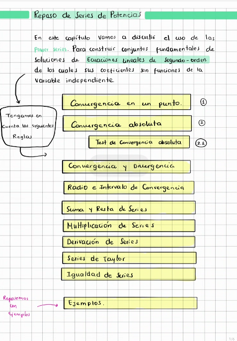

# Convergencia en un punto

Una power serie $\sum_{n=0}^{\infty} a_n (x-x_0)^n$ converge en un punto $x$ sí:

$$\lim_{m \to \infty} \sum_{n=0}^{m} a_n (x-x_0)^n$$

existe para ese $x$.

La serie con certeza converge para $x=x_o$ de ser así esta puede converger para todo $\forall$ x, o puede converger para algunos valores de $x$ y no para otros.

# Convergencia Absoluta

Las power series convergen absolutamente en un punto $x$ si:

$$\sum_{n=0}^{\infty} |a_n (x-x_0)^n| = \sum_{n=0}^{\infty} |a_n| |x-x_0|^n$$

Estas dos anteriores power series convergen.

### PROPIEDAD

- Si las POWER SERIES convergen de manera absoluta, implica que las POWER SERIES convergen. (Pero el contrario no es necesariamente real!)

# Test de Convergencia absoluta

Uno de los test más útiles para la Convergencia Absoluta de una power serie, es el Radio Test.

- Si $a_n \neq 0$ y sí para un valor fijo de x, tengo:

$$\lim_{n \to \infty} \left| \frac{a_{n+1}(x - x_0)^{n+1}}{a_n(x - x_0)^n} \right| = |x - x_0| \lim_{n \to \infty} \left| \frac{a_{n+1}}{a_n} \right| = \bbox[yellow, 2pt]{|x - x_0|L}$$

Así puedo decir que:

- Las power series convergen absolutamente en ese valor de x SÍ $|x - x_0|L < 1$
- Las power series divergen SÍ $|x - x_0|L > 1$.
- Pero si $|x - x_0|L = 1$ el TEST DE RADIO no concluye.

# Propiedad de Convergencia

- Si la serie de potencias $\sum_{n=0}^{\infty} a_n (x - x_0)^n$ **converge** en $x = x_1$, entonces converge absolutamente para:
  $$\bbox[#fff0f5, 5pt]{|x - x_0| < |x_1 - x_0|}$$
- Si **diverge** en $x = x_1$, entonces diverge para:
  $$|x - x_0| > |x_1 - x_0|$$

[output not shown]

# Series de Taylor

Una función $f(x)$ suave se puede representar como:
$$f(x) = \sum_{n=0}^{\infty} \frac{f^{(n)}(x_0)}{n!} (x-x_0)^n$$

# Igualdad de Series

Dos power series son iguales $\iff$ sus coeficientes son idénticos para todo $n$:
$$\sum a_n (x-x_0)^n = \sum b_n (x-x_0)^n \implies a_n = b_n$$

# Ejercicios

Para cada uno de los ejercicios del 1 al 6, determine el Radio de Convergencia:

1- $\quad \sum_{n=0}^\infty (x-3)^n$

3- $\quad \sum_{n=0}^\infty \frac{x^{2n}}{n!}$

Determine la Serie de Taylor en $x_o$:

8- $\quad e^x, \quad x_o =0$

10- $\quad x^2, \quad x_o =-1$